# Being a scientist doing a science

Rob Davies

## We are learning how to think critically for ourselves

*Active learning* works best even if it sometimes feel challenging

- Active learning is what you do when you ask or answer questions
- We will prompt you sometimes with Activate

**Activate**

Can you a picture a Psychologist? What do they look like? What kind of place do they work in?

## What we are going to do

We are going to engage with big ideas and difficult questions

1. **Being a psychologist:** How *should* we do science, how *do* we do science?
2. **How we try not to fool ourselves:** The logic of the scientific method, and how we should use it
3. **Why this is harder in Psychology:** People are semi-random, words are slippery, we can’t look inside everyone’s heads
4. **Science as a thing that is done by people:** History, community, inequity, and diversity

## Big ideas and difficult questions

- What is science?
- How do we do it?

## Science versus pseudoscience

We are surrounded by *pseduoscientific* claims and it’s hard to know what to believe. What is the difference between

1. *Scientific* claims like: phonics are a good way to learn to read
2. *Pseudoscience* claims like: vaccination causes Autism

**Reading**

Hansson (2025) presents a good outline of the issues

## Am I a crank or what?

- The problem is that *pseudoscience* can be presented to look like science and *cranks* can talk like scientists
- How do we tell the difference?
- Bright & Heesen (2023): the difference does not lie in whether we are right or wrong, doing good science or bad
- The difference lies in *communism* (Merton, 1942)

**Activate**

What psychological claims do you see online are *pseudoscientific*?

## Communism, universalism, disinteredness, organized skepticism

Merton (1942) sees the *ethos* of modern science as including:

- **Communism:** make your work freely available to others, and open to evaluation
- **Universalism:** evaluate ideas independent of who their sources are
- **Disinterestedness:** evaluate ideas based on evidence or reason, not preferences or interests
- **Organised skepticism:** suspension of judgment, openness to being wrong

## Doing science versus bullshitting

The difference between *science* and *pseudoscience* is like the difference between liars and bullshitters (Hicks et al., 2024):

- Liars give you a statement they know to be false, with the intention to deceive you
- Bullshitters *do not care* about the truth of their statements, whether or not they intend to deceive you about what they think

**AIs as bullshit machines**

Hicks et al. (2024) argue that AIs like ChatGPT *can **not*** intend truths

## Careful observations organized to enable reasoning

If we *do care* about the truth, how do we get to it?

- We have, at least since the Greek philosopher Aristotle, thought that we needed careful observations organized so that we can think effectively *reason* about them

**Reading**

Hepburn & Andersen (2026) presents a good outline of the issues

## What will our reasoning involve?

Most of the time, the forms of reasoning we use go in one of two directions

1. **Induction** $\rightarrow$ From observations to fundamental and general insights, regularities or principles
2. **Deduction** $\rightarrow$ To observations or tests, from fundamental and general insights, regularities or principles

## Being capable of being wrong

Maybe the core idea many psychological scientists assume about our work as scientists is that we must be **capable of being wrong:** roughly, this involves

1. Assuming a theory about the world or about people
2. Specifying a prediction that the theory implies, and testing it

**Reading**

But why is it being capable of being *wrong* that matters? We see the idea of **falsification** in the thinking of Popper (2005), as it is discussed by Meehl (1990)

## The history of science

- In thinking about science, it is useful to keep in mind the difference between (1.) what we think people *should* do (Merton, 1942; Popper, 2005) and (2.) what we *actually* do
- This leads us to think about history or the sociology of science in ways that are enlightening, especially when we want to engage with messy realities

**Reading**

If you have heard the words “paradigm shift” then you have been affected by Thomas Kuhn’s ideas about the history of science (Kuhn, 1970): we talk about these, next

## The normal business of science: solving puzzles

- Most of the time, scientists, working as members of a community or a tradition, work within a *shared understanding* of:
  - what problems are worth investigating
  - what solutions are possible
  - what methods can be used
- In the context of this **paradigm** (Kuhn, 1970), the scientist can spend their time figuring out solutions to the uncertainties that remain: *solving puzzles*

## Anomalies and revolutionary change

But over time scientists may come to see a (Kuhn, 1970):

> … persistent failure of the puzzles of normal science to come out as they should

A time of *crisis* ensues, leading to rejection of one paradigm, and acceptance of another

**Reading**

In Psychology, we have been through our own crises and now work in a revolutionary moment (Vazire, 2018): the *credibility revolution*

## Big ideas and difficult questions

**Activate**

What is the *next* revolution for psychological science? Are we already there?

## The *hardest* science: Why learning about people is hard

You will learn about *revolutionary* new ways of doing psychological science

- We will talk about
  - open science practices
  - reproducibility
  - requirements for building credible knowledge
- But why this revolution became necessary is worth thinking about

## The *hardest* science: Why learning about people is hard

Srivastava (2009) argues:

- Hard problems are embedded in complex systems
- Hard problems vary by local conditions
- Hard problems are difficult to quantify
  - *This* is why Psychology is **so challenging and so exciting**

## People vary, diverse in who we are, what we think and how we behave

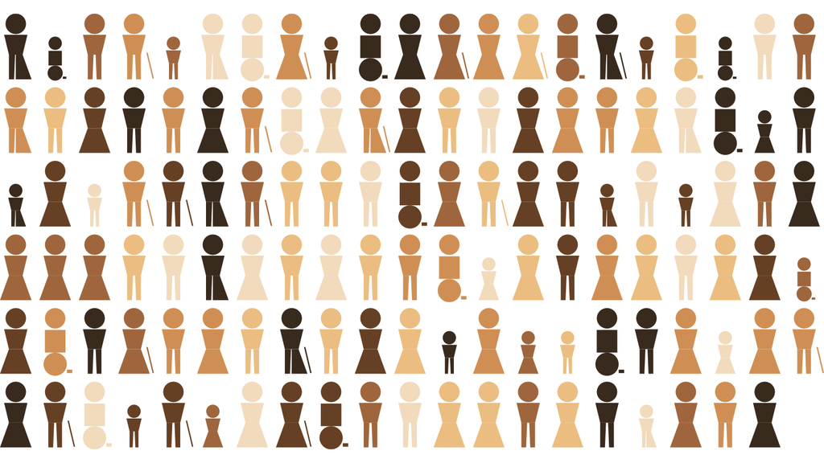

Figure 1: The people in any group will vary in many ways: just look around you

## We can *never* test all the people on all the things

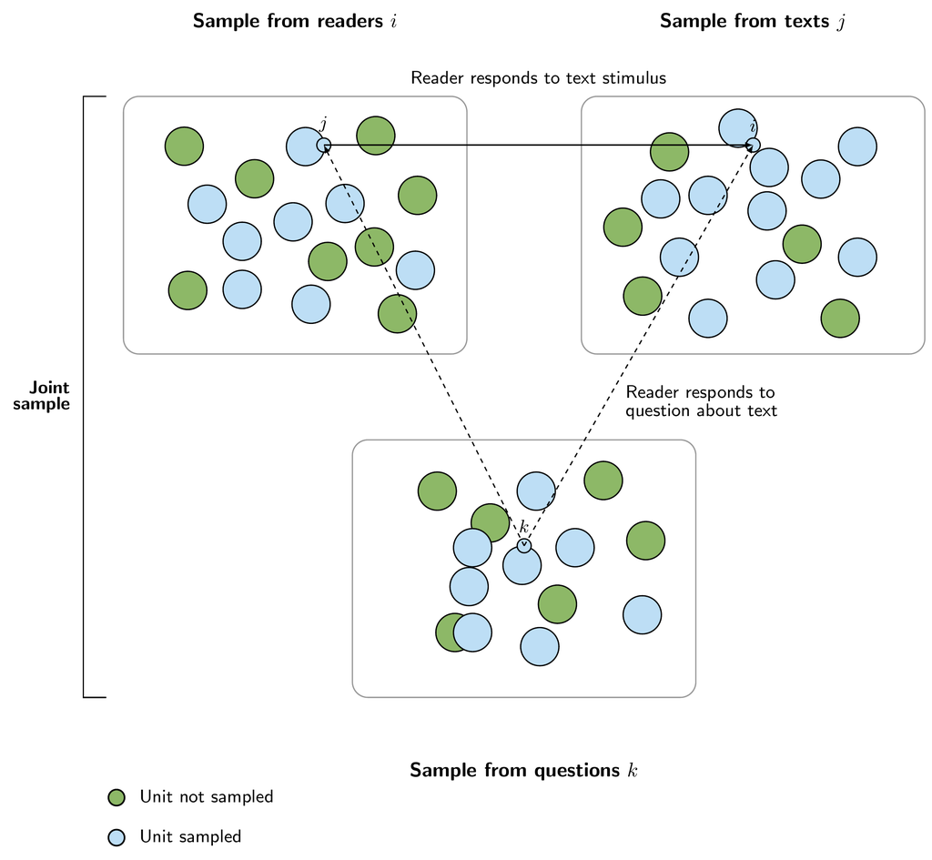

Figure 2: Normally, when we do psychological studies, we ask a sample of people to respond to a sample of stimuli

## We will work with data but numbers impose limits

We often work with *quantitative data*, numbers we record

- Data collection methods have to be repeatable $\rightarrow$ we need standardization
- We often identify categories of people or behaviours $\rightarrow$ classification involves choices
- Data need to be capable of summary $\rightarrow$ we ignore context

## We need to be aware of these limits

We can learn to work ably with quantitative data but that ability must come with *awareness* of the limits(Nguyen, 2024)

- To make data collection repeatable and observations capable of summary, we have to leave things out, stripping out context, and making classification choices that sometimes reflect biases or blindspots

**Activate**

Can you see the problems?: What about diagnostic categories? What about classification of gender, …?

## You are entering a field that has been through a period of revolution

The effects of revolution are present everywhere we do teaching and learning: Simine Vazire calls this the *credibility revolution* (Vazire, 2018). You will see it in our

- Emphasis on *transparency* or *open science*, so our procedures, materials, data and code are open to scrutiny
- Focus on *reproducibility*, so that our research can be verified
- Commitment to *integrity*

## How we think about and teach Psychological science is different now

- These changes have taken a while (Gelman & Vazire, 2021)
- but now represent the dominant culture in research-intensive universities (like Lancaster)
- These changes mean that *critical reflection* has a stronger role, now, for staff *and* students

**Reading**

Gelman & Vazire (2021) and Vazire (2018) are a good place to start but Gelman (2016) presents a *fierce* account

## Meehl’s thinking underlies the reforms in psychological science

Paul Meehls’ writings are interesting and *funny*. We learn from him that we should

- Be specific in the theory predictions that we test
- Understand that we will learn more when data *contradict our predictions*
- Than we can learn if observations match our predictions

**Reading**

Meehl wrote important and now-influential papers, including Meehl (1990)

## Doing science and the importance of falsification

Meehl (1990) built on Popper (2005) to argue that we need to be careful about the *logic*

**The logic**

If we assume a theory $T$ that predicts some observation $O$, we might be tempted to follow this logic:

1. If $T$ then $O$
2. Observe $O$
3. Decide $T$ is right
- But we would be mistaken (or at least *weakly* right) because there are so many possible reasons why we might see $O$

## Doing science and the importance of falsification

Meehl (1990) built on Popper (2005) to argue that we need to be careful about the *logic*

**The logic**

If we assume a theory $T$ that predicts some observation $O$, we *can* safely follow this logic:

1. If $T$ then $O$
2. Observe not-$O$
3. Decide $T$ is wrong
- This is *falsification* and it works because theory $T$ does not work if its prediction does not work: this logic is called *modus tollens* or the method of destruction

## The logic

**Activate**

It is not easy to think about the logic of science. That is true for everyone

- Respond to this element by trying to think of an example where you or someone you know has made a prediction (e.g., if you say that thing it will have that reaction) and then tested it (by saying the thing)
- Reflect on how your thinking was working then

## Theories and theory-like objects

If only it were that easy

## Theories and theory-like objects

- van Rooij (2022) points out that sometimes there are things that we call theories even though they are not theories
- Language is *slippery* so we need to be careful

**Theories and not theories**

Theories:

- Represent a thing we want to explain, a target like the mind
- In terms of a model, expressed in language, or images, or formal symbols

## Theories and theory-like objects

**Theories and not theories**

Theories are not:

- Stories or narratives we might use to describe what we are thinking about
- An acronym or collection of words or a one-word explanation
- A statistical model or data description or summary

## Auxiliary theories

Meehl (1990) explains that (1.) given a theory (2.) to make predictions we can test (3.) we often need *auxiliary theories*

**Auxiliary theories**

- If our theories are about how brains work or about psychological processes
- Then we also have to think about the way that a psychological process is linked to the behaviours we can observe
- Things like response production mechanisms

## We need to be *specific* in predictions

To get to a prediction we can test then, we need:

- A psychological theory about a process or a thing
- Auxiliary assumptions that gets us from the process or thing to what we can observe
- A specific account of what *exactly* we are predicting: is the behaviour going to increase or decrease, and by how much?

## The theory is not the hypothesis is not the statistical test result

**It will help you to keep these things separate**

- **Theories** are accounts of people and the things we do
- **Hypotheses** are based on theories, stated as predictions about how we vary
- **Test results** are aimed at hypotheses, based on observations about how people vary

## The theory is not the hypothesis is not the statistical test result

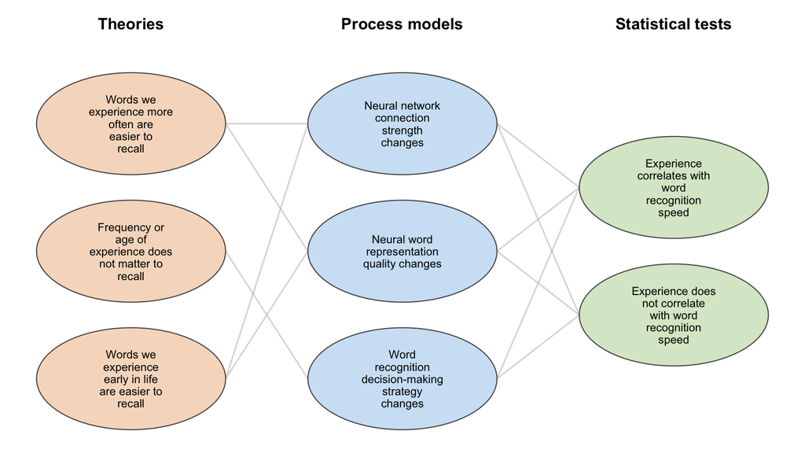

Figure 4: Different theories can imply the same process, and different processes can imply the same statistical test result

## Given the logic, the challenges: Measurements are imperfect

We cannot look directly inside people’s heads so we must rely on psychological measurements

**Validity $\sim$ Borsboom et al. (2004): Is our measure *valid*?**

A test is valid if:

1. the thing exists and
2. variations in the thing *causally* produce variations in measurement values

## Given the logic, the challenges: Measurements are imperfect

We cannot look directly inside people’s heads so we must rely on psychological measurements

**Reliability $\sim$ Revelle & Condon (2019): Is our measure *reliable*?**

“To what extent do scores measured at one time and one place with one instrument predict scores at another time or another place and perhaps measured with a diﬀerent instrument?”

## Given the logic, the challenges: Things vary, people vary

We often assume the same thing happens in the same way in everyone *but people vary* (Vasishth & Gelman, 2021)

## Given the logic, the challenges: People are kind of random

Let’s imagine we test a person (you) on a psychological attribute like your vocabulary knowledge.

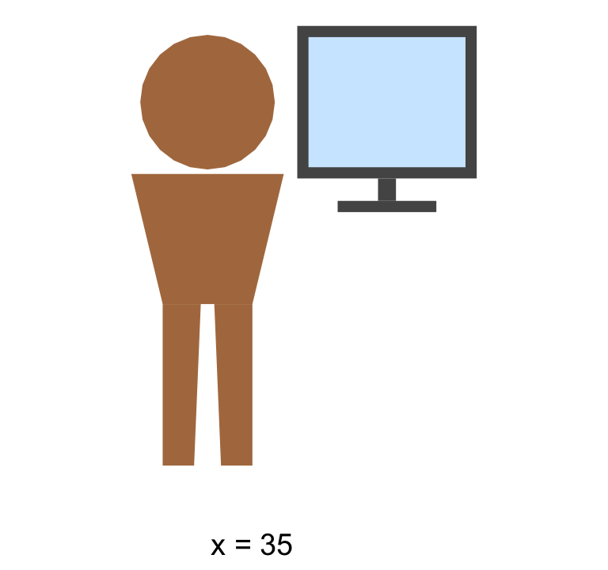

Figure 6: You do the vocabulary test

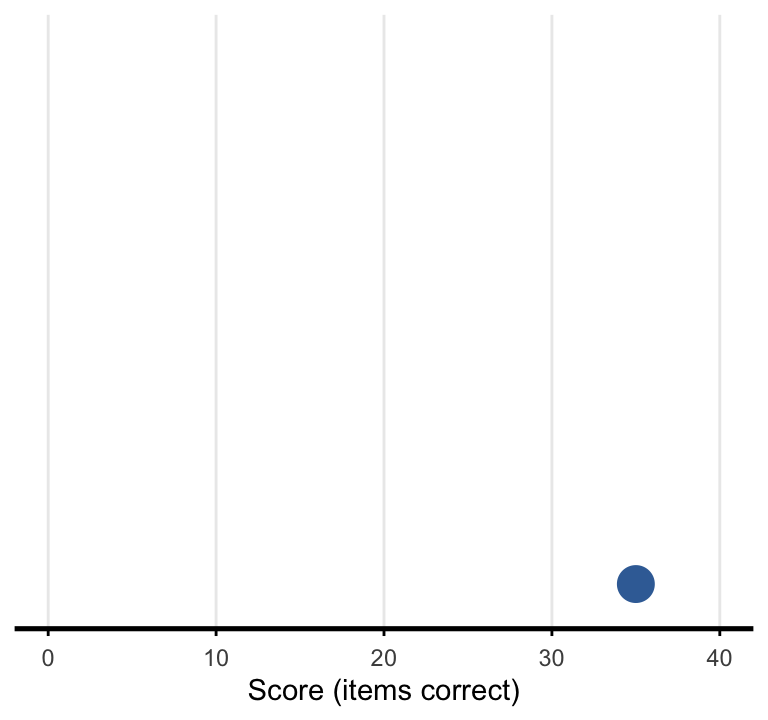

Figure 7: We record your score

## Given the logic, the challenges: People are kind of random

Now imagine we test two people (you and your neighbour) using the same vocabulary test

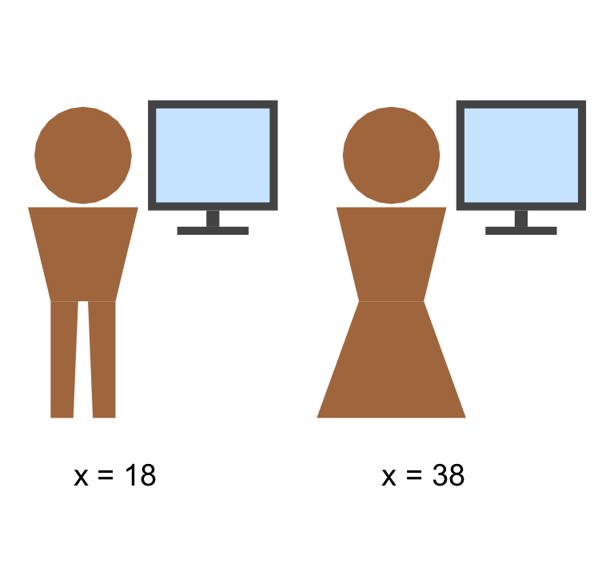

Figure 8: Two people complete the test

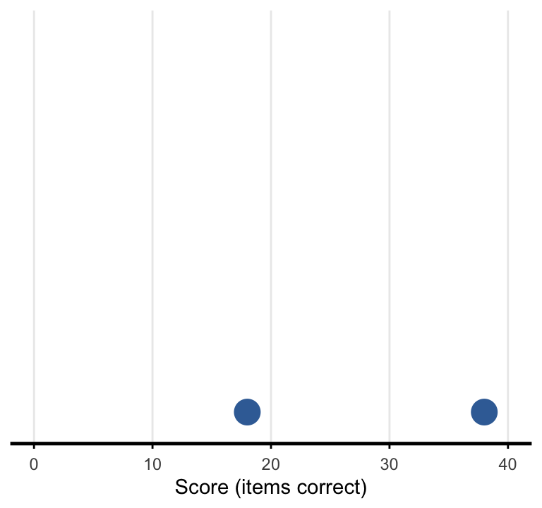

Figure 9: We record two scores

## Given the logic, the challenges: We usually only test *samples* of people

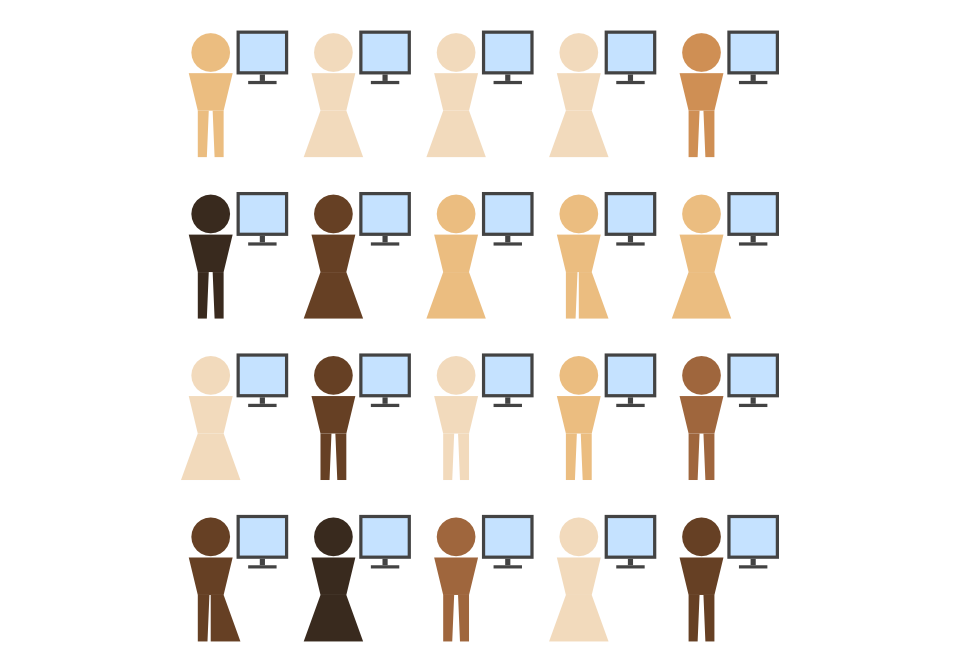

Figure 10: A sample of 20 people

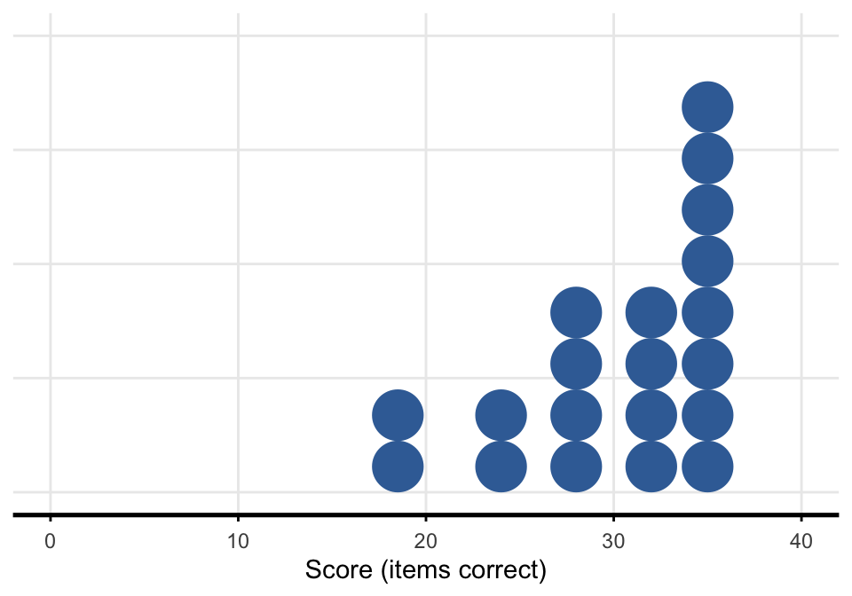

Figure 11: Their 20 scores: each point represents a person’s score

## Given the logic, the challenges: Fields of research involve many studies

If we ran the study again, we would draw a *different* sample of people each time

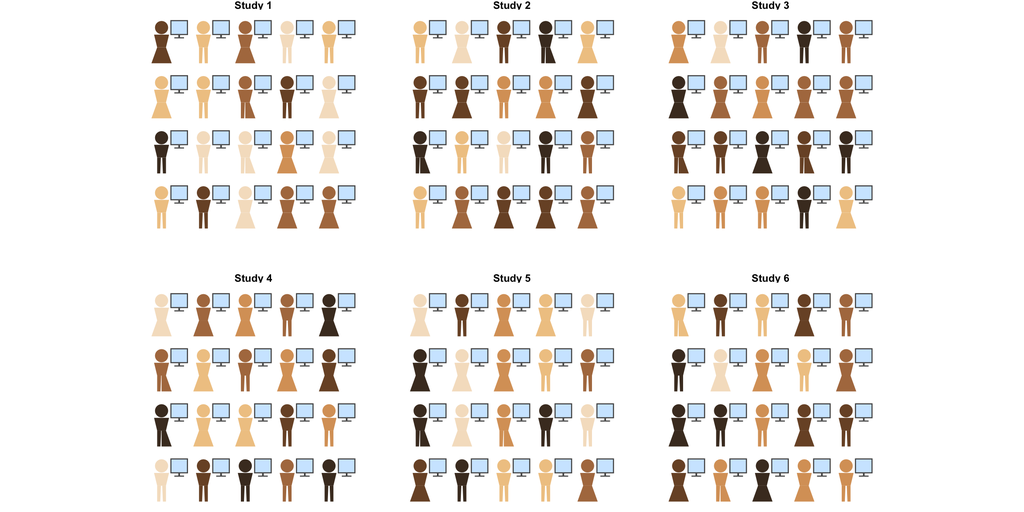

Figure 12: Six studies, each with its own sample of 20 people

## Given the logic, the challenges: Different samples of people will vary

No two samples look exactly alike, even when we’re recruiting people from the same population, and testing everyone with the same procedure

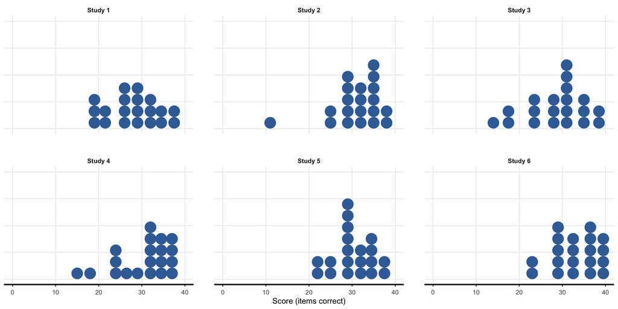

Figure 13: Score distributions from the same six studies

## The crud factor

- Meehl (1990)’s *crud factor*: “everything correlates to some extent with everything else”

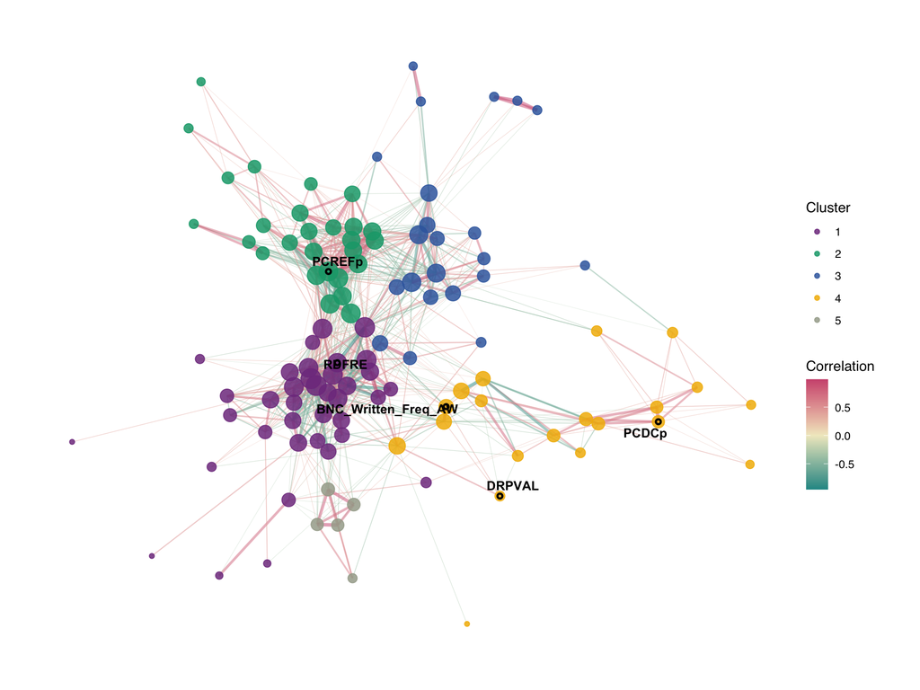

Figure 14: We can measure text structure prioperties in 100s of ways: Which ones matter?

## What does a hypothesis test show? False positives, false negatives

Because of these challenges, we are often concerned about *quality control* over our scientific process, and so we seek to limit the rate *over a series of studies* at which we run into:

- **False positives**: Concluding we have found something when there is nothing there
- **False negatives** Concluding there is nothing there when there is something

## The hardest science

**Activate**

I missed some challenges to psychological science. One is this: there are some things we may not be able *currently* to investigate scientifically. Can you name one?

## Science is a thing that is done by people

Our discussion has centered on:

- The logic of the scientific method (Meehl, 1990)
- The *ethos* or normative principles of modern science (Merton, 1942)
- High-level descriptions of the history of scientific progress (Kuhn, 1970)
- But we need to remember that *science is a thing that is done by people*

## Working with people you don’t know or like or respect or trust

- How is it that groups or communities or networks or societies of people
- Who may not know or like or respect or trust each other
- Can produce *this thing: science*, a progressively expanding understanding of the world?

**Reading**

Longino (2026) presents a good outline of the issues

## Communities in which critical perspectives are necessary and useful

Longino (2026) gives us a good place to start:

- We need free and open discussion of ideas because no-one is perfect and critical discussion should help us to avoid false or partial (personally biased) beliefs (Mill, 1859)
- In practice, this work could progress through the efforts of scientists to test each others’ theories (Popper, 2005)
- As individuals, alone, we cannot get to the truth but we can as a community agree on consensus understandings that will ultimately converge on the truth (Pierce, 1878/1958)

## Evaluation of quality, relevance, and interest (novelty or utility)

- How should we evaluate the quality, relevance, interest (novelty or utility) of research?
- In the last few decades, we have mostly relied on *peer review*
- What is peer review, why is it, and how does it work (or not)?

## What is peer review?

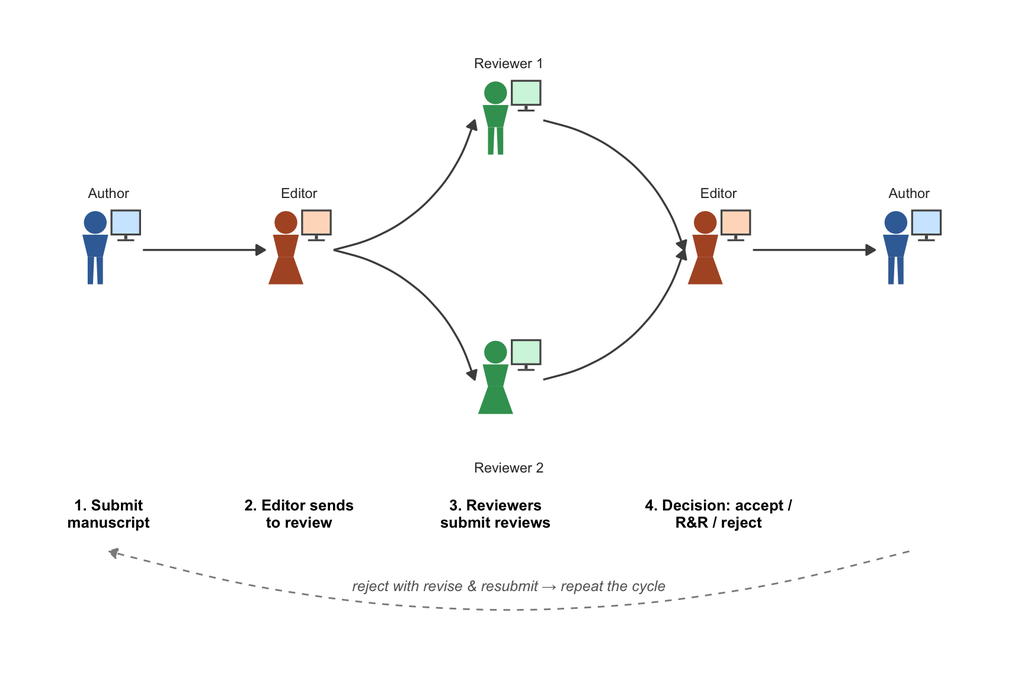

Figure 15: The peer-reviewed publication cycle: submission, review, and decision, repeating until accept or reject

## Peer review: new, imperfect, maybe coming to an end

- We see peer review emerging over time, in different forms in different places, and for different purposes (Spier, 2002)
- To understand why and how peer review emerges, we can *follow the money* (Baldwin, 2018):

> Scientists and their supporters cast expert refereeing—or “peer review,” as it was increasingly called—as the crucial process that ensured the credibility of science as a whole.

## What is peer review?

When you write a research report, you will adopt the structure, the content and the formatting we use when we report our work to our peers (other scientists)

- Introduction
- Methods
- Results
- Discussion

## The report is not the work: the hidden realities of lab science

Science is often messy: not all that complexity gets into print

- The things we study (people) are complicated, sometimes difficult to work with, and behave in semi-random ways
- In an ethnographic study of baby labs, Peterson (2016) shows that this means there are sometimes divergences
  - between ideas about how we should do science
  - what we say we did or found
  - what we actually did do

## Open science reforms and the evolution of practice

These challenges are why psychologists have come to adopt *open and reproducible science* practices (Munafò et al., 2017)

- Sharing our predictions, our materials, our data, and the code we use to do analysis
- Improving our methods training: *what we are doing here*
- Involving multiple labs in collaborative studies (e.g. McMillan et al., 2026: *Many babies*) to examine variability amongst participants, labs, and methods

## The excellent new science: *Many babies*

McMillan et al. (2026): studying thousands of babies across more than 200 labs worldwide, the challenges of infant research have come into sharper focus:

1. variability across infants, labs, and contexts appears to be the norm
2. larger samples sharpen measurement challenges
3. methodological choices are cultural choices

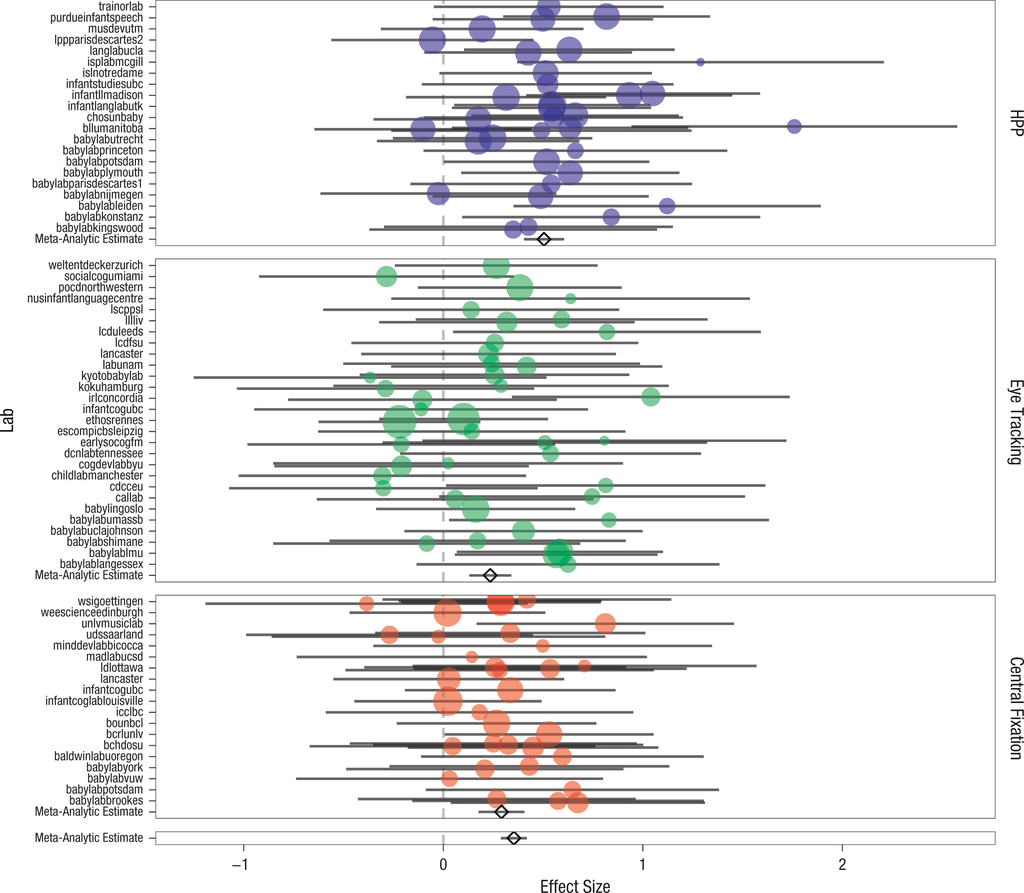

Many Babies Consortium‘ (2020): Infants’ preference for infant-directed speech is replicated across 67 labs but the effect is modulated by development, language experience and method

## The excellent new science: Adolescent well-being and digital technology

Everyone worries that adolescents’ digital technology use has a negative impact on psychological well-being but how we find out is complicated (Orben & Przybylski, 2019):

- Digital technology use may have a *small negative* impact
- But other factors are much more important, e.g., bullying
- Scientists need to think carefully about data quality, how big we think the effects should be, and what measurement methods we can use

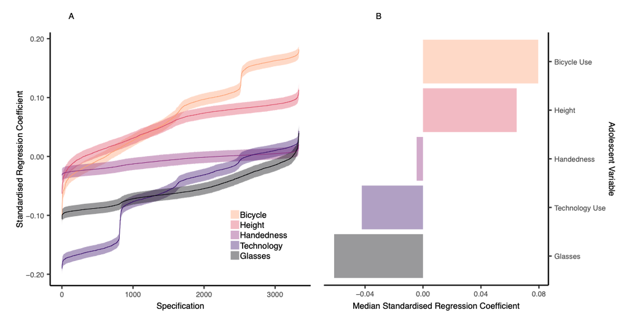

Orben & Przybylski (2019) Whether effects on well-being are positive or negative, large or small, depends on how you do your analysis. In some analyses, wearing glasses is more important than technology use

## Science is a thing that is done by people

**Activate**

How do you recognize if you are looking at *credible* science?

## Science is a social activity: fads, inequities and biases

- What do we study?
- Who does the studying?
- Fads, inequities and biases

## What do we study?

The volume of scientific outputs has grown rapidly over time: growth has been linked to societal changes

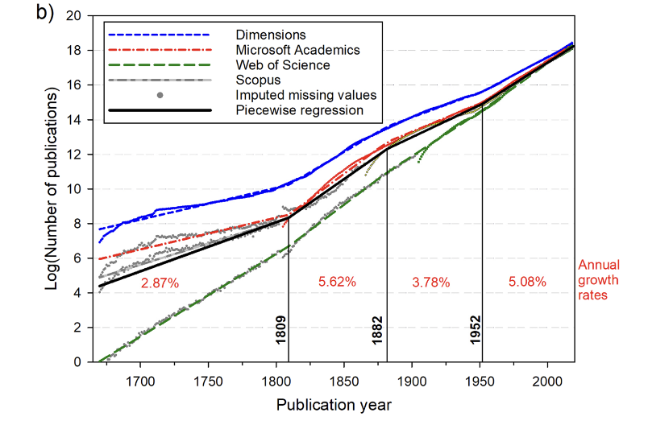

Bornmann et al. (2021): Growth in publications over time, split by candidate epochs

## What do we study?

Wieczorek et al. (2021) analysed the topics of over 500,000 research article abstracts: different methods and different topics are studied at different times

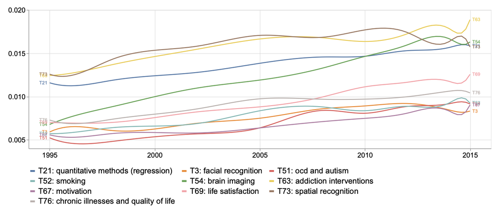

Wieczorek et al. (2021): We see increasing discourse around specialized, applied and thematically driven topics like addiction, brain imaging or facial recognition

## Who does the studying?

Who does what? Does it matter who you are? In a sense, it *should not* matter.

Merton (1942) says:

> The acceptance or rejection of claims … is not to depend on the personal attributes of their protagonist [of who you are, your] race, nationality, class and personal qualities …

Likewise

> careers [should be] open to talents [no matter who you are]

## Biases and inequities

Who does what? Does it matter who you are? In a sense, it *should not* matter. But there is plenty of evidence that gender, race, language, geography and gender *do* matter to:

- What you study
- Your chances of success
- The diversity of the scientific ecosystem of ideas

**Reading**

Graves et al. (2022) present an account of inequality in science, advocating the construction of a socially responsible science system

## Biases and inequities: language

- Amano et al. (2023): while most people are non-native English speakers, we face difficulties at every stage

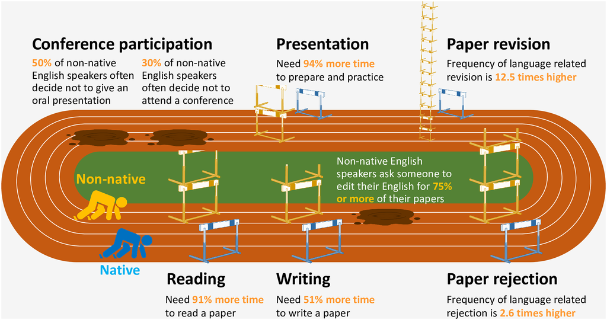

Amano et al. (2023): Estimated disadvantages for non-native English speakers

## Biases and inequities: geography

There is a brutal geography at work: whose ideas get heard?

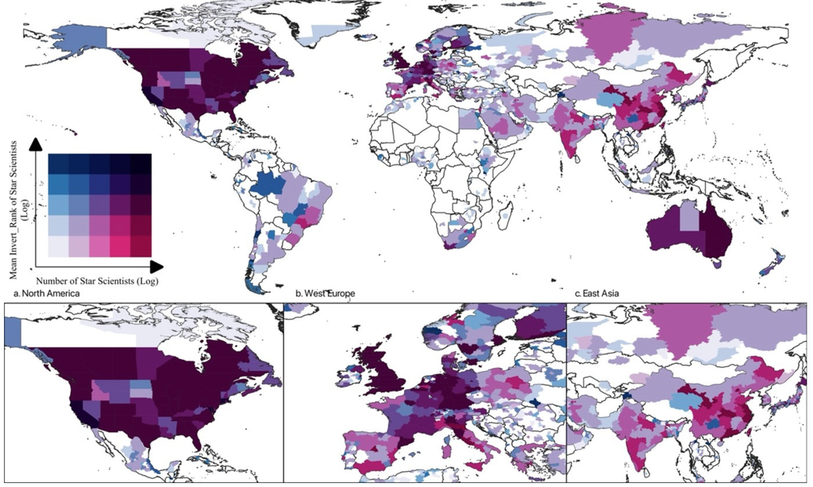

Rodríguez-Pose et al. (2026): For much of the emerging world, the map of frontier research is close to empty

## Biases and inequities: geography

There is a brutal geography at work: whose ideas get heard?

- Gomez et al. (2022) analyzed 20 million papers across nearly 35 years and 150 fields:
  - work from outside a global elite is mostly unrecognized
- Zumel Dumlao & Teplitskiy (2025) analyze data from physics journals:
  - if reviewers favor work from their own country (homophily)
  - and most reviewers come from just a few countries
  - then authors from those countries enjoy an advantage

## Biases and inequities: gender and ethnicity

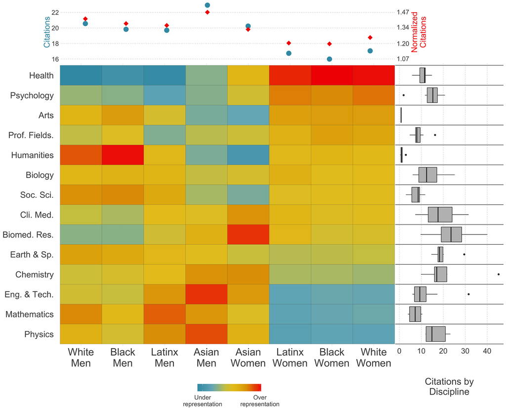

Kozlowski et al. (2022) analyzed about 7 million articles to find gender and ethnicity disparities in who does what science

## Biases and inequities: gender and ethnicity

- Kozlowski et al. (2022)’s results show:
  - While White authors publish everywhere, *a privilege of choice*,
  - Minoritized authors tend to publish in scientific disciplines and on research topics that reflect their gendered and racialized social identities
- Unequal representation in science leads to underinvestigation of particular topics and may block innovation

## Diversity *would be* helpful

Hofstra et al. (2020):

> historically underrepresented groups often draw relations between ideas and concepts that have been traditionally missed or ignored

## Diversity *would be* helpful, maybe not for those doing the representing

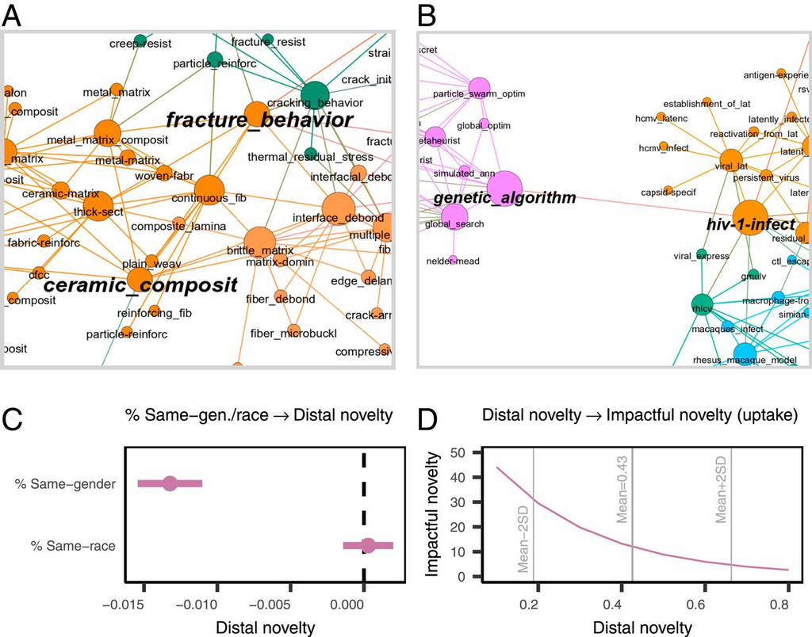

Hofstra et al. (2020) looked at about 1.2 million doctoral dissertations: people from under-represented groups tend to make more distant *innovative* links between concepts more often but innovative work based on more distant links tends to have less impact

## Diversity *would be* helpful

Graves et al. (2022) call for socially responsible science grounded in principles of equity

**Activate**

Think about your experiences and the experiences of the people you know: what group of people or topic do you think *should* be studied but is now ignored?

## Big ideas and difficult questions

1. Ideas about how we should do science diverge from observations about what we do
2. But we still need to be guided by ideas about communism, universalism, disinterestedness and skepticism
3. We need to be capable of being wrong
4. But getting the logic to work *for us* is tricky when the thing we study *people* are varied and kind of random, and the measures we use are imperfect
5. We will get there, and exciting new research shows the way

## References

Amano, T., Ramírez-Castañeda, V., Berdejo-Espinola, V., Borokini, I., Chowdhury, S., Golivets, M., González-Trujillo, J. D., Montaño-Centellas, F., Paudel, K., White, R. L., & Veríssimo, D. (2023). The manifold costs of being a non-native English speaker in science. *PLOS Biology*, *21*(7), e3002184. https://doi.org/10.1371/journal.pbio.3002184

Baldwin, M. (2018). Scientific Autonomy, Public Accountability, and the Rise of “Peer Review” in the Cold War United States. *Isis*, *109*(3), 538–558. https://doi.org/10.1086/700070

Bornmann, L., Haunschild, R., & Mutz, R. (2021). Growth rates of modern science: A latent piecewise growth curve approach to model publication numbers from established and new literature databases. *Humanities & Social Sciences Communications*, *8*(1). https://doi.org/10.1057/s41599-021-00903-w

Borsboom, D., Mellenbergh, G. J., & van Heerden, J. (2004). The concept of validity. *Psychological Review*, *111*(4), 1061–1071. https://doi.org/10.1037/0033-295X.111.4.1061

Bright, L. K., & Heesen, R. (2023). To be scientific is to be communist. *Social Epistemology*, *37*(3), 249–258. https://doi.org/10.1080/02691728.2022.2156308

Gelman, A. (2016). *What has happened down here is the winds have changed*. Web log post. https://statmodeling.stat.columbia.edu/2016/09/21/what-has-happened-down-here-is-the-winds-have-changed/

Gelman, A., & Vazire, S. (2021). Why Did It Take So Many Decades for the Behavioral Sciences to Develop a Sense of Crisis Around Methodology and Replication? *Journal of Methods and Measurement in the Social Sciences*, *12*(1). https://doi.org/10.2458/jmmss.3062

Gomez, C. J., Herman, A. C., & Parigi, P. (2022). Leading countries in global science increasingly receive more citations than other countries doing similar research. *Nature Human Behaviour*, *6*(7), 919–929. https://doi.org/10.1038/s41562-022-01351-5

Graves, J. L., Kearney, M., Barabino, G., & Malcom, S. (2022). Inequality in science and the case for a new agenda. *Proceedings of the National Academy of Sciences*, *119*(10), e2117831119. https://doi.org/10.1073/pnas.2117831119

Hansson, S. O. (2025). Science and Pseudo-Science. In E. N. Zalta & U. Nodelman (Eds.), *The Stanford encyclopedia of philosophy* (Fall 2025). https://plato.stanford.edu/archives/fall2025/entries/pseudo-science/; Metaphysics Research Lab, Stanford University.

Hepburn, B., & Andersen, H. (2026). Scientific Method. In E. N. Zalta & U. Nodelman (Eds.), *The Stanford encyclopedia of philosophy* (Fall 2026). https://plato.stanford.edu/archives/fall2026/entries/scientific-method/; Metaphysics Research Lab, Stanford University.

Hicks, M. T., Humphries, J., & Slater, J. (2024). ChatGPT is bullshit. *Ethics and Information Technology*, *26*(2), 38. https://doi.org/10.1007/s10676-024-09775-5

Hofstra, B., Kulkarni, V. V., Munoz-Najar Galvez, S., He, B., Jurafsky, D., & McFarland, D. A. (2020). The Diversity–Innovation Paradox in Science. *Proceedings of the National Academy of Sciences*, *117*(17), 9284–9291. https://doi.org/10.1073/pnas.1915378117

Kozlowski, D., Larivière, V., Sugimoto, C. R., & Monroe-White, T. (2022). Intersectional inequalities in science. *Proceedings of the National Academy of Sciences*, *119*(2), e2113067119. https://doi.org/10.1073/pnas.2113067119

Kuhn, T. S. (1970). *The structure of scientific revolutions* ([2d ed., enl). University of Chicago Press.

Longino, H. (2026). The Social Dimensions of Scientific Knowledge. In E. N. Zalta & U. Nodelman (Eds.), *The Stanford encyclopedia of philosophy* (Fall 2026). https://plato.stanford.edu/archives/fall2026/entries/scientific-knowledge-social/; Metaphysics Research Lab, Stanford University.

Many Babies Consortium‘. (2020). Quantifying Sources of Variability in Infancy Research Using the Infant-Directed-Speech Preference. *Advances in Methods and Practices in Psychological Science*, *3*(1), 24–52. https://doi.org/10.1177/2515245919900809

McMillan, B. T. M., Baumgartner, H. A., Bergmann, C., Frank, M. C., Hamlin, J. K., Kampis, D., Kline Struhl, M., Ko, E.-S., Kosie, J. E., Lew-Williams, C., Lucca, K., Schuwerk, T., Soderstrom, M., Visser, I., Yuen, F. L., Zettersten, M., & Byers-Heinlein, K. (2026). What 5000 babies can tell us about developing minds and how to study them. *Communications Psychology*, *4*(1), 92. https://doi.org/10.1038/s44271-026-00477-w

Meehl, P. E. (1990). Why summaries of research on psychological theories are often uninterpretable. *Psychological Reports*, *66*(1), 195–244. https://doi.org/10.2466/pr0.1990.66.1.195

Merton, R. K. (1942). A Note on Science and Democracy. *Journal of Legal and Political Sociology*, *1*(1 and 2), 115–126.

Mill, J. S. (1859). *On Liberty* (Reprinted 1974, 1982). Penguin. (Original work published John W. Parker and Son)

Munafò, M. R., Nosek, B. A., Bishop, D. V. M., Button, K. S., Chambers, C. D., Percie Du Sert, N., Simonsohn, U., Wagenmakers, E. J., Ware, J. J., & Ioannidis, J. P. A. (2017). A manifesto for reproducible science. *Nature Human Behaviour*, *1*(1), 1–9. https://doi.org/10.1038/s41562-016-0021

Nguyen, C. T. (2024). The Limits of Data. *Issues in Science and Technology*, *40*(2), 94–101. https://doi.org/10.58875/LUXD6515

Orben, A., & Przybylski, A. K. (2019). The association between adolescent well-being and digital technology use. *Nature Human Behaviour*, *3*(2), 173–182. https://doi.org/10.1038/s41562-018-0506-1

Peterson, D. (2016). The Baby Factory: Difficult Research Objects, Disciplinary Standards, and the Production of Statistical Significance. *Socius*, *2*, 2378023115625071. https://doi.org/10.1177/2378023115625071

Pierce, C. S. (1958). How to make our ideas clear. In *Selected writings* (pp. 114–136). Dover Publications. (Original work published 1878)

Popper, K. (2005). *The logic of scientific discovery* (2nd ed.). Routledge. https://doi.org/10.4324/9780203994627

Revelle, W., & Condon, D. M. (2019). Reliability from α to ω: A tutorial. *Psychological Assessment*, *31*(12), 1395–1411. https://doi.org/10.1037/pas0000754

Rodríguez-Pose, A., Xiang, L., & Lee, N. (2026, January 26). *The brutal geography of global elite scientific research - LSE Impact*. LSE Impact - Understanding impact; practice in academic research. https://blogs.lse.ac.uk/impactofsocialsciences/2026/01/26/the-brutal-geography-of-global-elite-scientific-research/

Spier, R. (2002). The history of the peer-review process. *Trends in Biotechnology*, *20*(8), 357–358. https://doi.org/10.1016/S0167-7799(02)01985-6

Srivastava, S. (2009). *Making progress in the hardest science*. Web log post. https://thehardestscience.com/2009/03/14/making-progress-in-the-hardest-science/

van Rooij, I. (2022). Psychological models and their distractors. *Nature Reviews Psychology*, *1*(3), 127–128. https://doi.org/10.1038/s44159-022-00031-5

Vasishth, S., & Gelman, A. (2021). How to embrace variation and accept uncertainty in linguistic and psycholinguistic data analysis. *Linguistics*, *59*(5), 1311–1342. https://doi.org/10.1515/ling-2019-0051

Vazire, S. (2018). Implications of the credibility revolution for productivity, creativity, and progress. *Perspectives on Psychological Science*, *13*(4), 411–417. https://doi.org/10.1177/1745691617751884

Wieczorek, O., Unger, S., Riebling, J., Erhard, L., Koß, C., & Heiberger, R. (2021). Mapping the field of psychology: Trends in research topics 1995–2015. *Scientometrics*, *126*(12), 9699–9731. https://doi.org/10.1007/s11192-021-04069-9

Zumel Dumlao, J. M., & Teplitskiy, M. (2025). Geographical diversity of peer reviewers shapes author success. *Proceedings of the National Academy of Sciences*, *122*(33), e2507394122. https://doi.org/10.1073/pnas.2507394122